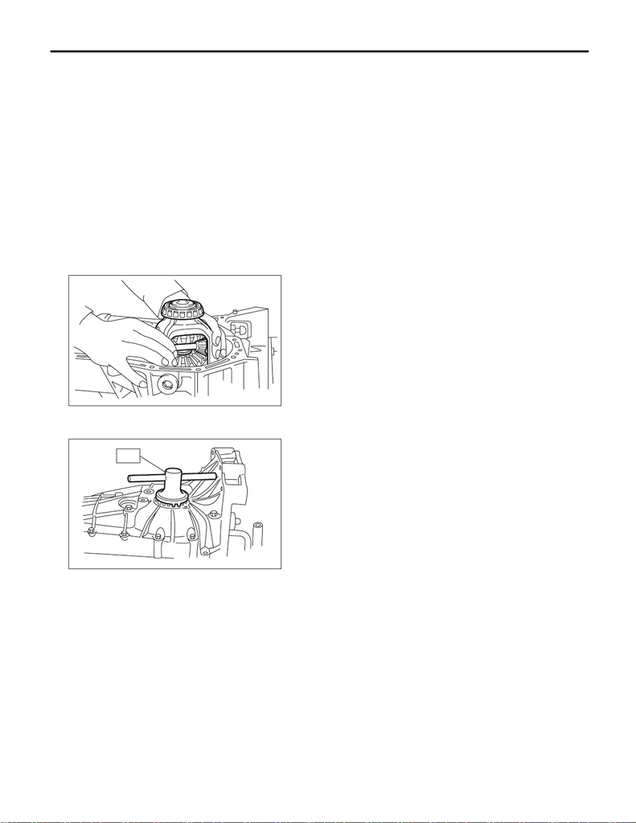

6MT(TY75)-111

Front Differential Assembly

MANUAL TRANSMISSION AND DIFFERENTIAL

18.Front Differential Assembly

A: REMOVAL

1) Remove the manual transmission assembly from the vehicle. <Ref. to 6MT(TY75)-25, REMOVAL, Manual

Transmission Assembly.>

2) Remove the transfer case together with the extension case assembly. <Ref. to 6MT(TY75)-51, REMOV-

AL, Transfer Case and Extension Case Assembly.>

3) Remove the transmission case. <Ref. to 6MT(TY75)-79, REMOVAL, Transmission Case.>

4) Remove the drive pinion shaft assembly. <Ref. to 6MT(TY75)-92, REMOVAL, Drive Pinion Shaft Assem-

bly.>

5) Remove the main shaft assembly. <Ref. to 6MT(TY75)-83, REMOVAL, Main Shaft Assembly for Single-

Range.>

6) Remove the front differential assembly.

NOTE:

• Do not confuse the right and left taper roller bearing outer races.

• Be careful not to damage the oil seal of differential side retainer.

7) Remove the differential side retainers using ST.

ST 18630AA010 WRENCH COMPL RETAINER

8) Remove the taper roller bearing outer race from the transmission case.

ST 398527700 PULLER ASSY

MT-02469

MT-02667

ST

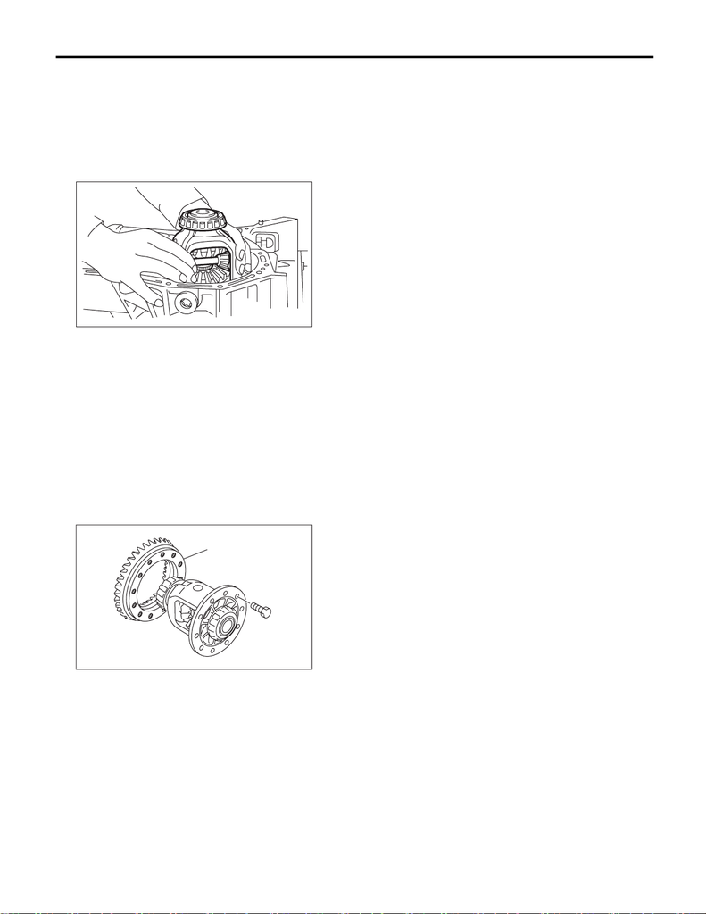

6MT(TY75)-112

Front Differential Assembly

MANUAL TRANSMISSION AND DIFFERENTIAL

B: INSTALLATION

1) Install the differential side retainers using ST.

ST 18630AA010 WRENCH COMPL RETAINER

2) Install the taper roller bearing outer race to the transmission case.

3) Install the front differential assembly.

CAUTION:

Make sure the oil seal lip is not folded.

4) Install the main shaft assembly. <Ref. to 6MT(TY75)-83, INSTALLATION, Main Shaft Assembly for Sin-

gle-Range.>

5) Install the drive pinion shaft assembly. <Ref. to 6MT(TY75)-92, INSTALLATION, Drive Pinion Shaft As-

sembly.>

6) Install the transmission case. <Ref. to 6MT(TY75)-80, INSTALLATION, Transmission Case.>

7) Install the transfer case together with the extension case assembly. <Ref. to 6MT(TY75)-53, INSTALLA-

TION, Transfer Case and Extension Case Assembly.>

8) Install the manual transmission assembly to the vehicle. <Ref. to 6MT(TY75)-30, INSTALLATION, Manual

Transmission Assembly.>

C: DISASSEMBLY

1. DIFFERENTIAL CASE ASSEMBLY

1) Loosen the twelve bolts and remove hypoid driven gear.

MT-02469

MT-02744

(A)

(A) Hypoid driven gear

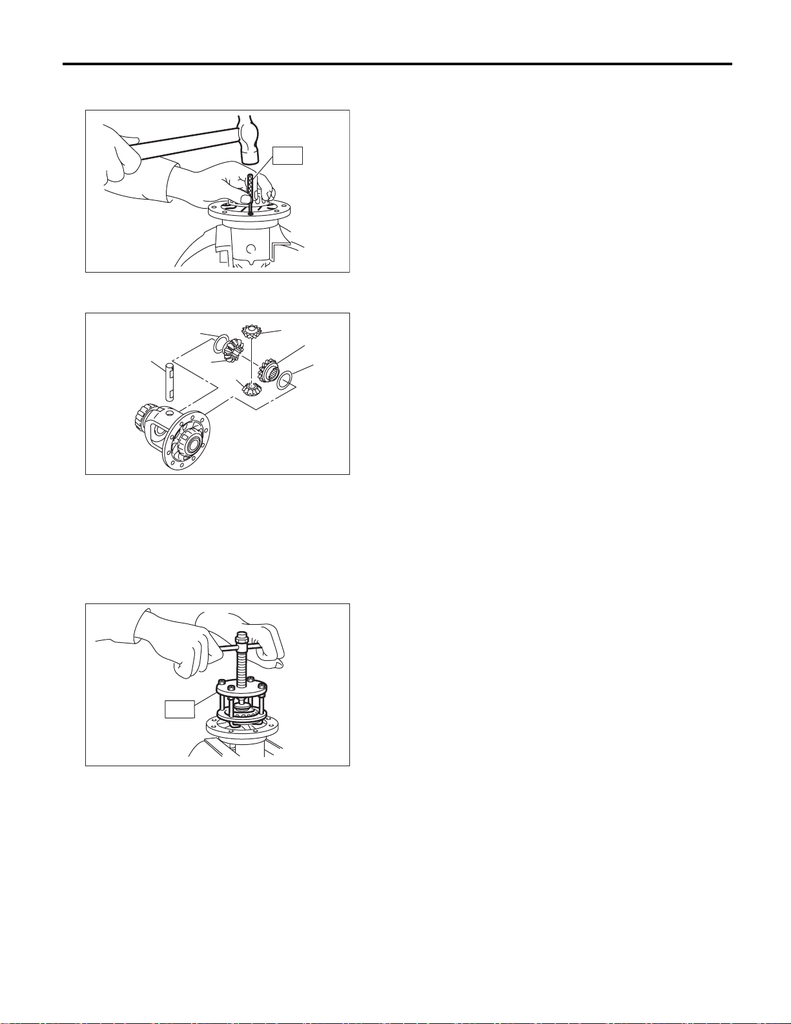

6MT(TY75)-113

Front Differential Assembly

MANUAL TRANSMISSION AND DIFFERENTIAL

2) Drive out the straight pin from differential assembly toward hypoid driven gear side.

ST 899904100 STRAIGHT PIN REMOVER

3) Pull out the pinion shaft, and remove the differential bevel pinion, differential bevel gear and adjusting

washer.

4) Using the ST, remove the taper roller bearing inner race.

ST 899524100 PULLER SET

MT-00276

ST

MT-02745

(A)

(D)

(D)

(C)

(C)

(B)

(B)

(A) Pinion shaft

(B) Differential bevel pinion

(C) Differential bevel gear

(D) Adjusting washer

MT-02698

ST

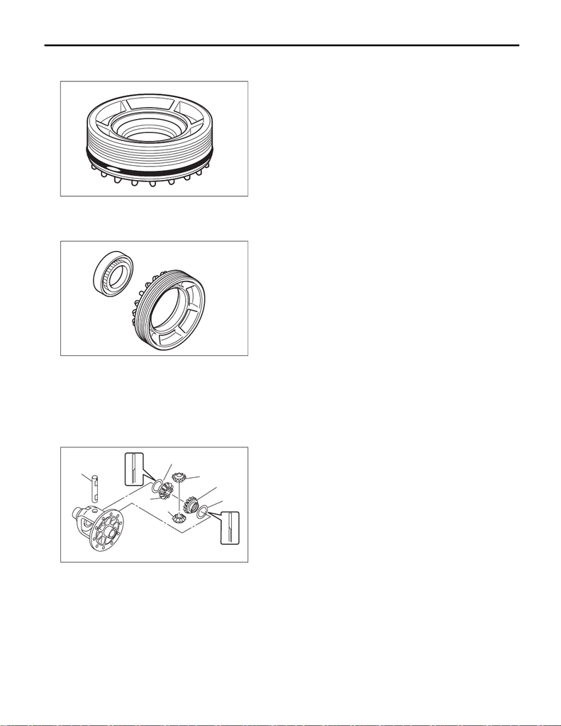

6MT(TY75)-114

Front Differential Assembly

MANUAL TRANSMISSION AND DIFFERENTIAL

2. SIDE RETAINER

1) Remove the O-rings.

2) Remove the oil seal.

NOTE:

Remove using the flat tip screwdriver.

D: ASSEMBLY

1. DIFFERENTIAL CASE ASSEMBLY

1) Install the differential bevel gear and differential bevel pinion together with adjusting washer, and insert the

pinion shaft.

NOTE:

Face the chamfered side of adjusting washer toward differential bevel gear.

MT-02742

MT-02743

MT-02774

(A)

(D)

(D)

(C)

(C)

(B)

(B)

(A) Pinion shaft

(B) Differential bevel pinion

(C) Differential bevel gear

(D) Adjusting washer

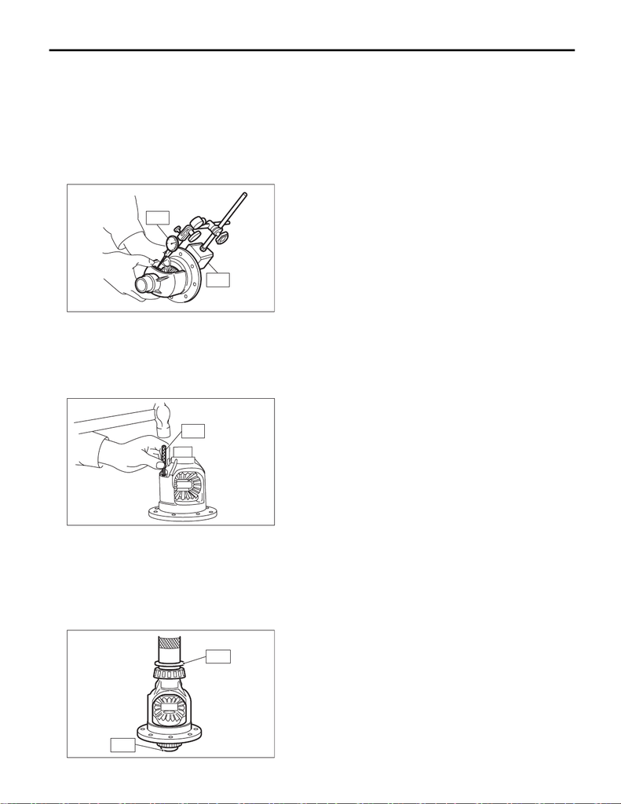

6MT(TY75)-115

Front Differential Assembly

MANUAL TRANSMISSION AND DIFFERENTIAL

2) Measure the backlash between the differential bevel gear and differential bevel pinion. Adjust the back-

lash if not within specified limit. <Ref. to 6MT(TY75)-118, DIFFERENTIAL BEVEL PINION GEAR BACK-

LASH, INSPECTION, Front Differential Assembly.>

NOTE:

Be sure the differential bevel pinion gear teeth contact adjacent gear teeth during measurement.

Standard backlash

0.13 — 0.18 mm (0.0051 — 0.0071 in)

ST1 498247001 MAGNET BASE

ST2 498247100 DIAL GAUGE

3) Align the pinion shaft pin hole with the differential case pin hole, and drive the straight pin into the holes

from the hypoid driven gear side using the ST.

NOTE:

Use a new straight pin. After driving the straight pin, crimp the area around the hole in order to prevent the

straight pin from coming out.

ST 899904100 STRAIGHT PIN REMOVER

4) Attach the taper roller bearing inner race.

CAUTION:

Do not apply a load in excess of 10 kN (1 ton, 1.1 US ton, 1.0 Imp ton).

NOTE:

Be careful when handling because the taper roller bearing and the outer race are used as a set.

ST1 499277100 BUSHING 1-2 INSTALLER

ST2 398497701 ADAPTER

MT-00285

ST1

ST2

MT-02775

ST

MT-00287

ST1

ST2

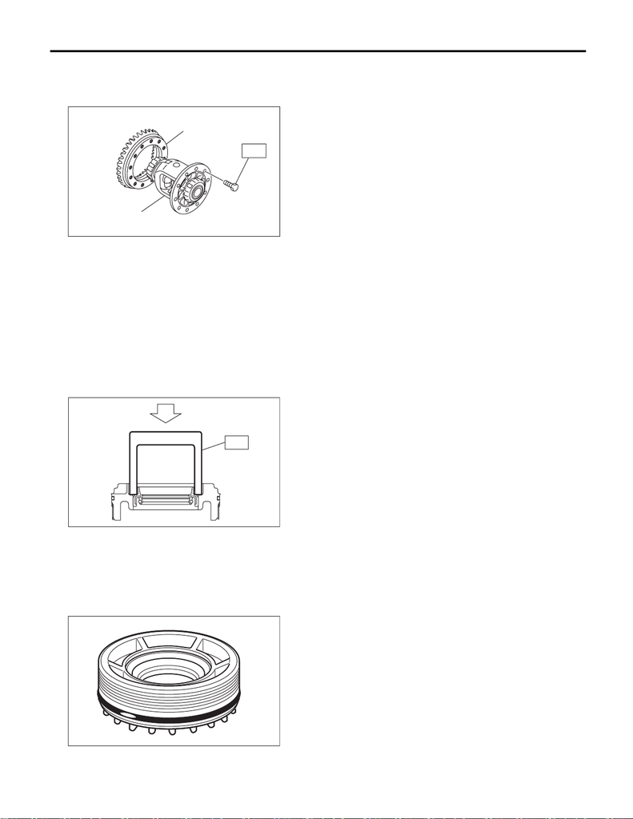

6MT(TY75)-116

Front Differential Assembly

MANUAL TRANSMISSION AND DIFFERENTIAL

5) Install the hypoid driven gear using twelve bolts.

Tightening torque:

T: 62 N·m (6.3 kgf-m, 45.7 ft-lb)

2. DIFFERENTIAL SIDE RETAINER

1) Using the ST, install the oil seal by lightly tapping with a plastic hammer.

NOTE:

• Use a new oil seal.

• Apply transmission gear oil to the oil seal lips, and install the oil seal while being careful not to deform the

lip.

• Check the identification marks (L, R), and attach the oil seals RH and LH.

ST 18675AA000 DIFFERENTIAL SIDE OIL SEAL INSTALLER

2) Install the O-rings.

NOTE:

• Use new O-rings.

• Apply gear oil to O-ring.

• Do not stretch or damage the O-ring.

• Install the O-ring after hypoid driven gear backlash adjustment and completion of tooth contact inspection.

MT-02746

(A)

(B)

T

(A) Hypoid driven gear

(B) Differential case

MT-00289

ST

MT-02742

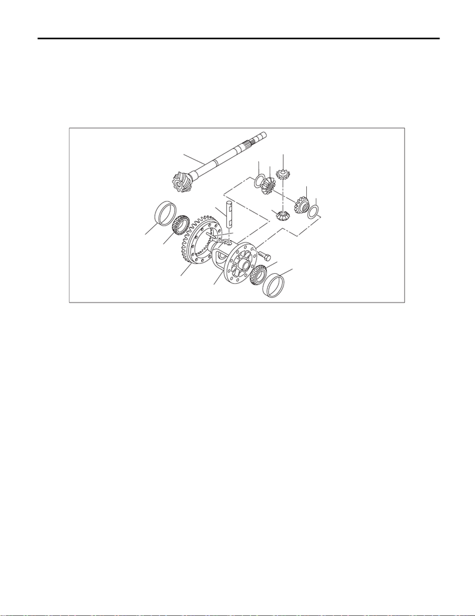

6MT(TY75)-117

Front Differential Assembly

MANUAL TRANSMISSION AND DIFFERENTIAL

E: INSPECTION

Repair or replace the differential gear in the following cases:

• When the hypoid driven gear and drive pinion shaft tooth surfaces are damaged, excessively worn, or

seized.

• When the roller bearing on the drive pinion shaft has a worn or damaged roller path.

• When there is damage, wear or seizure of the differential bevel pinion, differential bevel gear, adjusting

washer, pinion shaft or straight pin.

• When the differential case sliding surfaces are worn or damaged.

(A) Drive pinion shaft

(B) Hypoid driven gear

(C) Pinion shaft

(D) Straight pin

(E) Adjusting washer

(F) Differential bevel gear

(G) Differential bevel pinion

(H) Taper roller bearing inner race

(I) Taper roller bearing outer race

(J) Differential case

MT-03202

(I)

(H)

(D)

(C)

(B)

(E)

(F)

(G)

(F)

(E)

(A)

(G)

(H)

(I)

(J)

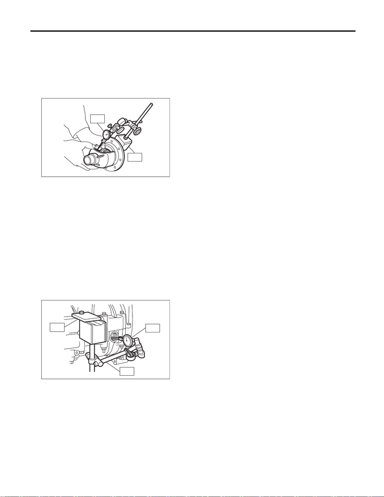

6MT(TY75)-118

Front Differential Assembly

MANUAL TRANSMISSION AND DIFFERENTIAL

1. DIFFERENTIAL BEVEL PINION GEAR BACKLASH

Measure the backlash between the differential bevel gear and differential bevel pinion. Adjust the backlash

if not within specified limit. <Ref. to 6MT(TY75)-119, ADJUSTMENT, Front Differential Assembly.>

Standard backlash

0.13 — 0.18 mm (0.0051 — 0.0071 in)

ST1 498247001 MAGNET BASE

ST2 498247100 DIAL GAUGE

2. HYPOID DRIVEN GEAR BACKLASH

1) Set the ST1, ST2 and ST3. Insert the dial gauge probe through drain plug hole so that the probe comes

in contact with the tooth surface on the right corner, and check the backlash.

ST1 498247001 MAGNET BASE

ST2 498247100 DIAL GAUGE

ST3 498255400 PLATE

2) Install SUBARU genuine axle shafts to both sides, rotate in the inversion direction so that the gauge con-

tacts the tooth surface, and read the dial gauge.

NOTE:

If the backlash is outside the specified range, adjust it by turning the differential side retainers on the left and

right side.

Backlash

0.13 — 0.18 mm (0.0051 — 0.0071 in)

Part No. 38415AA100 Axle shaft

MT-00285

ST1

ST2

MT-00293

ST1

ST2

ST3

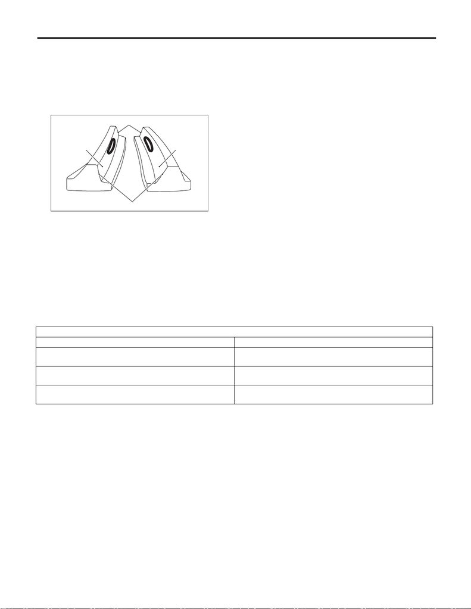

6MT(TY75)-119

Front Differential Assembly

MANUAL TRANSMISSION AND DIFFERENTIAL

3. TOOTH CONTACT OF HYPOID DRIVEN GEAR

Check tooth contact of hypoid driven gear as follows: Apply a thin uniform coat of red lead on both teeth sur-

faces on 3 or 4 teeth of the hypoid gear. Move the hypoid driven gear back and forth by turning the transmis-

sion main shaft until a definite contact pattern is developed on the hypoid driven gear, and judge whether

face contact is correct. When the contact pattern is not correct, adjust. <Ref. to 6MT(TY75)-119, ADJUST-

MENT, Front Differential Assembly.>

• Tooth contact is correct.

F: ADJUSTMENT

1. DIFFERENTIAL BEVEL PINION GEAR BACKLASH

1) Disassemble the front differential assembly. <Ref. to 6MT(TY75)-112, DISASSEMBLY, Front Differential

Assembly.>

2) Select the adjusting washer from the table and install.

3) Adjust until the standard value is obtained.

Backlash:

Standard

0.13 — 0.18 mm (0.0051 — 0.0071 in)

MT-01402

(B)

(D)

(C)

(A)

(A) Toe

(B) Coast side

(C) Heel

(D) Drive side

Adjusting washer

Part No. Thickness mm (in)

803038021

0.925 — 0.950

(0.0364 — 0.0374)

803038022

0.975 — 1.000

(0.0384 — 0.0394)

803038023

1.025 — 1.050

(0.0404 — 0.0413)

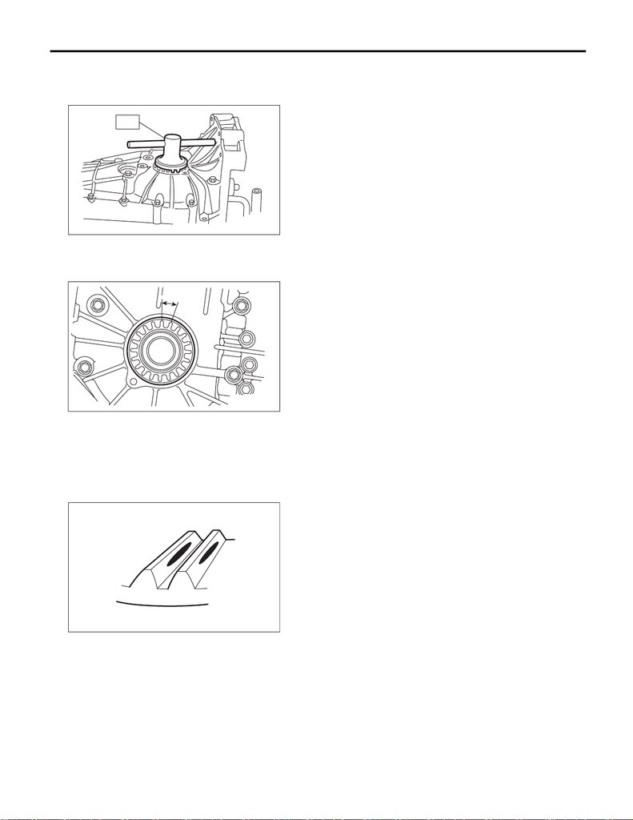

6MT(TY75)-120

Front Differential Assembly

MANUAL TRANSMISSION AND DIFFERENTIAL

2. HYPOID DRIVEN GEAR BACKLASH

Adjust the backlash by turning the differential side retainers on the left and right side.

ST 18630AA010 WRENCH COMPL RETAINER

NOTE:

Each time the differential side retainer rotates by one notch (A), the backlash changes by 0.05 mm (0.0020

in).

3. TOOTH CONTACT OF HYPOID DRIVEN GEAR

1) Adjust until correct teeth contact is obtained.

2) Check tooth contact, and perform the adjustment as follows.

• Correct tooth contact

Check item: Tooth contact surface is slightly shifted toward the toe side under a no-load condition.

(When driving, it moves towards the heel side.)

MT-02667

ST

A

MT-02671

(A)

(B)

MT-01401

(A) Toe side

(B) Heel side

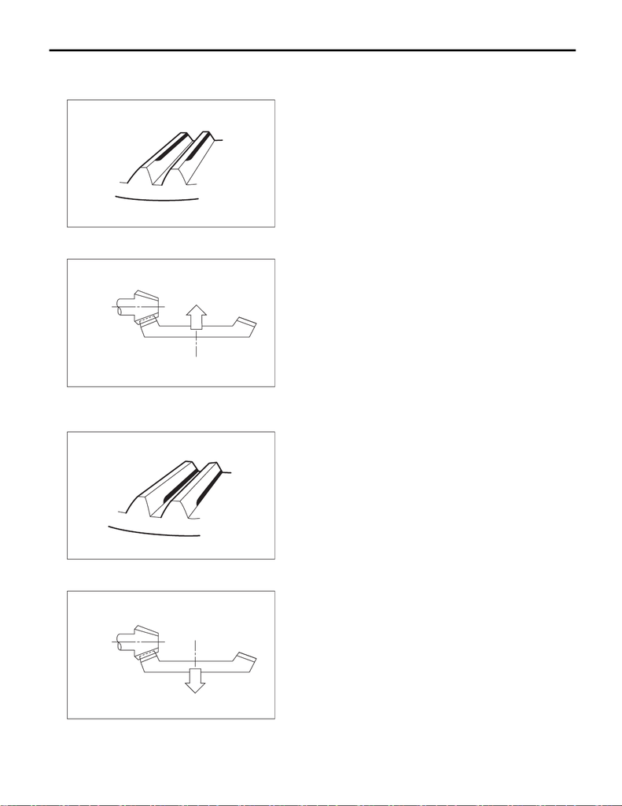

6MT(TY75)-121

Front Differential Assembly

MANUAL TRANSMISSION AND DIFFERENTIAL

• Face contact

Check item: Backlash is too large.

Contact pattern

Corrective action: Tighten the differential side retainer to move the hypoid driven gear closer to the drive pin-

ion shaft.

• Flank contact

Check item: Backlash is too small.

Contact pattern

Corrective action: Loosen the differential side retainer to move the hypoid driven gear away from the drive

pinion shaft.

AT-00208

MT-01799

AT-00209

MT-01800

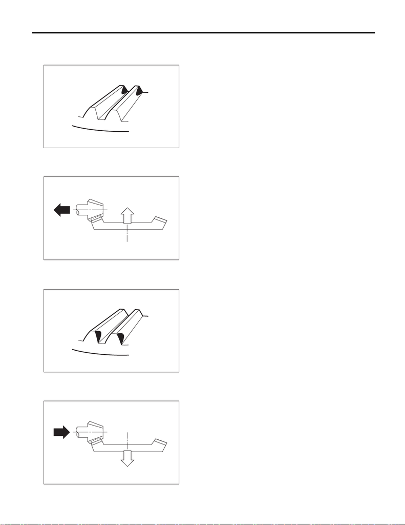

6MT(TY75)-122

Front Differential Assembly

MANUAL TRANSMISSION AND DIFFERENTIAL

• Toe contact (inside contact)

Check item: Teeth contact area is too small.

Contact pattern

Corrective action: Increase the thickness of drive pinion shim and tighten the differential side retainer to move

the hypoid driven gear closer to the drive pinion shaft according to the procedure for bringing drive pinion

shaft away from hypoid driven gear.

• Heel contact (outside end contact)

Check item: Teeth contact area is too small.

Contact pattern

Corrective action: Reduce thickness of the drive pinion shim according to the procedures for moving the drive

pinion shaft closer to hypoid driven gear. Also loosen the differential side retainer to move the hypoid driven

gear away from the drive pinion shaft.

AT-00210

AT-00213

AT-00211

AT-00212